# Risk Factor Analysis

## Outcome Variable

**Outcome Variable:** sstunted

## Predictor Variables

**Intervention Variable:** meducyrs

**Adjustment Set:**

- arm
- W_mage
- feducyrs
- hhwealth_quart
- W_mhtcm
- W_mwtkg
- W_mbmi
- W_gagebrth
- W_birthwt
- W_birthlen
- single
- W_nrooms
- impsan
- delta_W_mage
- delta_feducyrs
- delta_hhwealth_quart
- delta_W_mhtcm
- delta_W_mwtkg
- delta_W_mbmi
- delta_W_gagebrth
- delta_W_birthwt
- delta_W_birthlen
- delta_single
- delta_W_nrooms
- delta_impsan

## Stratifying Variables

The analysis was stratified on these variable(s):

- agecat
- studyid
- country

## Data Summary

| agecat | studyid | country | meducyrs | sstunted | n_cell | n |
| --- | --- | --- | --- | --- | --- | --- |
| Birth | CMC-V-BCS-2002 | INDIA | High | 0 | 49 | 92 |
| Birth | CMC-V-BCS-2002 | INDIA | High | 1 | 2 | 92 |
| Birth | CMC-V-BCS-2002 | INDIA | Low | 0 | 16 | 92 |
| Birth | CMC-V-BCS-2002 | INDIA | Low | 1 | 0 | 92 |
| Birth | CMC-V-BCS-2002 | INDIA | Medium | 0 | 23 | 92 |
| Birth | CMC-V-BCS-2002 | INDIA | Medium | 1 | 2 | 92 |
| Birth | COHORTS | GUATEMALA | High | 0 | 177 | 842 |
| Birth | COHORTS | GUATEMALA | High | 1 | 1 | 842 |
| Birth | COHORTS | GUATEMALA | Low | 0 | 384 | 842 |
| Birth | COHORTS | GUATEMALA | Low | 1 | 7 | 842 |
| Birth | COHORTS | GUATEMALA | Medium | 0 | 270 | 842 |
| Birth | COHORTS | GUATEMALA | Medium | 1 | 3 | 842 |
| Birth | COHORTS | INDIA | High | 0 | 668 | 5216 |
| Birth | COHORTS | INDIA | High | 1 | 10 | 5216 |
| Birth | COHORTS | INDIA | Low | 0 | 1683 | 5216 |
| Birth | COHORTS | INDIA | Low | 1 | 73 | 5216 |
| Birth | COHORTS | INDIA | Medium | 0 | 2716 | 5216 |
| Birth | COHORTS | INDIA | Medium | 1 | 66 | 5216 |
| Birth | COHORTS | PHILIPPINES | High | 0 | 1156 | 3050 |
| Birth | COHORTS | PHILIPPINES | High | 1 | 13 | 3050 |
| Birth | COHORTS | PHILIPPINES | Low | 0 | 882 | 3050 |
| Birth | COHORTS | PHILIPPINES | Low | 1 | 18 | 3050 |
| Birth | COHORTS | PHILIPPINES | Medium | 0 | 966 | 3050 |
| Birth | COHORTS | PHILIPPINES | Medium | 1 | 15 | 3050 |
| Birth | EE | PAKISTAN | High | 0 | 5 | 239 |
| Birth | EE | PAKISTAN | High | 1 | 2 | 239 |
| Birth | EE | PAKISTAN | Low | 0 | 171 | 239 |
| Birth | EE | PAKISTAN | Low | 1 | 44 | 239 |
| Birth | EE | PAKISTAN | Medium | 0 | 16 | 239 |
| Birth | EE | PAKISTAN | Medium | 1 | 1 | 239 |

[output cut: 396 more lines]

The following strata were considered:

- agecat: 24 months, studyid: CMC-V-BCS-2002, country: INDIA
- agecat: 24 months, studyid: COHORTS, country: GUATEMALA
- agecat: 24 months, studyid: COHORTS, country: INDIA
- agecat: 24 months, studyid: COHORTS, country: PHILIPPINES
- agecat: 24 months, studyid: EE, country: PAKISTAN
- agecat: 24 months, studyid: GMS-Nepal, country: NEPAL
- agecat: 24 months, studyid: IRC, country: INDIA
- agecat: 24 months, studyid: JiVitA-3, country: BANGLADESH
- agecat: 24 months, studyid: JiVitA-4, country: BANGLADESH
- agecat: 24 months, studyid: LCNI-5, country: MALAWI
- agecat: 24 months, studyid: MAL-ED, country: BANGLADESH
- agecat: 24 months, studyid: MAL-ED, country: BRAZIL
- agecat: 24 months, studyid: MAL-ED, country: INDIA
- agecat: 24 months, studyid: MAL-ED, country: NEPAL
- agecat: 24 months, studyid: MAL-ED, country: PERU
- agecat: 24 months, studyid: MAL-ED, country: SOUTH AFRICA
- agecat: 24 months, studyid: MAL-ED, country: TANZANIA, UNITED REPUBLIC OF
- agecat: 24 months, studyid: NIH-Birth, country: BANGLADESH
- agecat: 24 months, studyid: NIH-Crypto, country: BANGLADESH
- agecat: 24 months, studyid: PROBIT, country: BELARUS
- agecat: 24 months, studyid: PROVIDE, country: BANGLADESH
- agecat: 24 months, studyid: TanzaniaChild2, country: TANZANIA, UNITED REPUBLIC OF
- agecat: 24 months, studyid: ZVITAMBO, country: ZIMBABWE
- agecat: 6 months, studyid: CMC-V-BCS-2002, country: INDIA
- agecat: 6 months, studyid: COHORTS, country: GUATEMALA
- agecat: 6 months, studyid: COHORTS, country: INDIA
- agecat: 6 months, studyid: COHORTS, country: PHILIPPINES
- agecat: 6 months, studyid: EE, country: PAKISTAN
- agecat: 6 months, studyid: GMS-Nepal, country: NEPAL
- agecat: 6 months, studyid: Guatemala BSC, country: GUATEMALA
- agecat: 6 months, studyid: IRC, country: INDIA
- agecat: 6 months, studyid: JiVitA-3, country: BANGLADESH
- agecat: 6 months, studyid: JiVitA-4, country: BANGLADESH
- agecat: 6 months, studyid: LCNI-5, country: MALAWI
- agecat: 6 months, studyid: MAL-ED, country: BANGLADESH
- agecat: 6 months, studyid: MAL-ED, country: BRAZIL
- agecat: 6 months, studyid: MAL-ED, country: INDIA
- agecat: 6 months, studyid: MAL-ED, country: NEPAL
- agecat: 6 months, studyid: MAL-ED, country: PERU
- agecat: 6 months, studyid: MAL-ED, country: SOUTH AFRICA
- agecat: 6 months, studyid: MAL-ED, country: TANZANIA, UNITED REPUBLIC OF
- agecat: 6 months, studyid: NIH-Birth, country: BANGLADESH
- agecat: 6 months, studyid: NIH-Crypto, country: BANGLADESH
- agecat: 6 months, studyid: PROBIT, country: BELARUS
- agecat: 6 months, studyid: PROVIDE, country: BANGLADESH
- agecat: 6 months, studyid: SAS-CompFeed, country: INDIA
- agecat: 6 months, studyid: SAS-FoodSuppl, country: INDIA
- agecat: 6 months, studyid: TanzaniaChild2, country: TANZANIA, UNITED REPUBLIC OF
- agecat: 6 months, studyid: ZVITAMBO, country: ZIMBABWE
- agecat: Birth, studyid: CMC-V-BCS-2002, country: INDIA
- agecat: Birth, studyid: COHORTS, country: GUATEMALA
- agecat: Birth, studyid: COHORTS, country: INDIA
- agecat: Birth, studyid: COHORTS, country: PHILIPPINES
- agecat: Birth, studyid: EE, country: PAKISTAN
- agecat: Birth, studyid: GMS-Nepal, country: NEPAL
- agecat: Birth, studyid: IRC, country: INDIA
- agecat: Birth, studyid: JiVitA-3, country: BANGLADESH
- agecat: Birth, studyid: JiVitA-4, country: BANGLADESH
- agecat: Birth, studyid: MAL-ED, country: BANGLADESH
- agecat: Birth, studyid: MAL-ED, country: BRAZIL
- agecat: Birth, studyid: MAL-ED, country: INDIA
- agecat: Birth, studyid: MAL-ED, country: NEPAL
- agecat: Birth, studyid: MAL-ED, country: PERU
- agecat: Birth, studyid: MAL-ED, country: SOUTH AFRICA
- agecat: Birth, studyid: MAL-ED, country: TANZANIA, UNITED REPUBLIC OF
- agecat: Birth, studyid: NIH-Birth, country: BANGLADESH
- agecat: Birth, studyid: NIH-Crypto, country: BANGLADESH
- agecat: Birth, studyid: PROBIT, country: BELARUS
- agecat: Birth, studyid: PROVIDE, country: BANGLADESH
- agecat: Birth, studyid: SAS-CompFeed, country: INDIA
- agecat: Birth, studyid: ZVITAMBO, country: ZIMBABWE

### Dropped Strata

Some strata were dropped due to rare outcomes:

- agecat: Birth, studyid: CMC-V-BCS-2002, country: INDIA
- agecat: Birth, studyid: COHORTS, country: GUATEMALA
- agecat: Birth, studyid: EE, country: PAKISTAN
- agecat: Birth, studyid: GMS-Nepal, country: NEPAL
- agecat: Birth, studyid: IRC, country: INDIA
- agecat: Birth, studyid: MAL-ED, country: BANGLADESH
- agecat: Birth, studyid: MAL-ED, country: BRAZIL
- agecat: Birth, studyid: MAL-ED, country: INDIA
- agecat: Birth, studyid: MAL-ED, country: NEPAL
- agecat: Birth, studyid: MAL-ED, country: PERU
- agecat: Birth, studyid: MAL-ED, country: SOUTH AFRICA
- agecat: Birth, studyid: MAL-ED, country: TANZANIA, UNITED REPUBLIC OF
- agecat: Birth, studyid: NIH-Crypto, country: BANGLADESH
- agecat: Birth, studyid: PROBIT, country: BELARUS
- agecat: Birth, studyid: PROVIDE, country: BANGLADESH
- agecat: 6 months, studyid: EE, country: PAKISTAN
- agecat: 6 months, studyid: GMS-Nepal, country: NEPAL
- agecat: 6 months, studyid: MAL-ED, country: BANGLADESH
- agecat: 6 months, studyid: MAL-ED, country: BRAZIL
- agecat: 6 months, studyid: MAL-ED, country: INDIA
- agecat: 6 months, studyid: MAL-ED, country: NEPAL
- agecat: 6 months, studyid: MAL-ED, country: PERU
- agecat: 6 months, studyid: MAL-ED, country: SOUTH AFRICA
- agecat: 6 months, studyid: MAL-ED, country: TANZANIA, UNITED REPUBLIC OF
- agecat: 6 months, studyid: NIH-Birth, country: BANGLADESH
- agecat: 6 months, studyid: PROVIDE, country: BANGLADESH
- agecat: 6 months, studyid: SAS-FoodSuppl, country: INDIA
- agecat: 6 months, studyid: TanzaniaChild2, country: TANZANIA, UNITED REPUBLIC OF
- agecat: 24 months, studyid: EE, country: PAKISTAN
- agecat: 24 months, studyid: GMS-Nepal, country: NEPAL
- agecat: 24 months, studyid: MAL-ED, country: BANGLADESH
- agecat: 24 months, studyid: MAL-ED, country: BRAZIL
- agecat: 24 months, studyid: MAL-ED, country: INDIA
- agecat: 24 months, studyid: MAL-ED, country: NEPAL
- agecat: 24 months, studyid: MAL-ED, country: PERU
- agecat: 24 months, studyid: MAL-ED, country: SOUTH AFRICA
- agecat: 24 months, studyid: MAL-ED, country: TANZANIA, UNITED REPUBLIC OF
- agecat: 24 months, studyid: PROBIT, country: BELARUS
- agecat: 24 months, studyid: TanzaniaChild2, country: TANZANIA, UNITED REPUBLIC OF

## Methods Detail

We’re interested in the causal parameters $E[Y_a]$ for all values of $a \in \mathcal{A}$. These parameters represent the mean outcome if, possibly contrary to fact, we intervened to set all units to have $A=a$. Under the randomization and positivity assumptions, these are identified by the statistical parameters $\psi_a=E_W[E_{Y|A,W}(Y|A=a,W)]$. In addition, we’re interested in the mean of $Y$, $E[Y]$ under no intervention (the observed mean). We will estimate these parameters by using SuperLearner to fit the relevant likelihood factors – $E_{Y|A,W}(Y|A=a,W)$ and $p(A=a|W)$, and then updating our likelihood fit using a joint TMLE.

For unadjusted analyses ($W=\{\}$), initial likelihoods were estimated using Lrnr_glm to estimate the simple $E(Y|A)$ and Lrnr_mean to estimate $p(A)$. For adjusted analyses, a small library containing Lrnr_glmnet, Lrnr_xgboost, and Lrnr_mean was used.

Having estimated these parameters, we will then use the delta method to estimate relative risks and attributable risks relative to a prespecified baseline level of $A$.

# Results Detail

## Results Plots

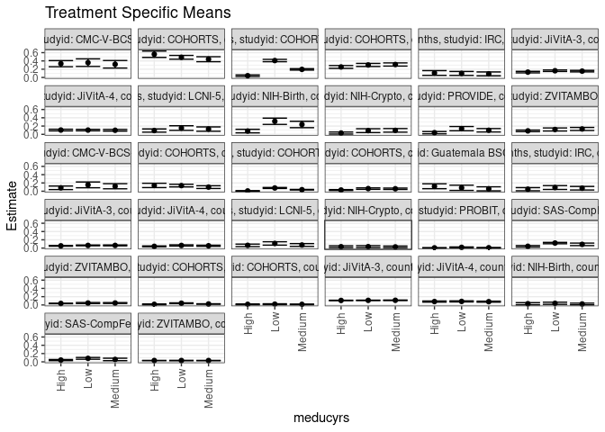

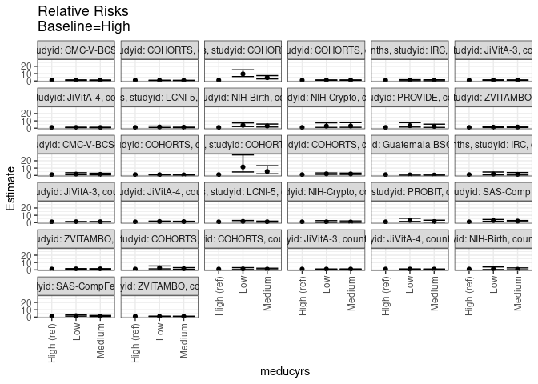

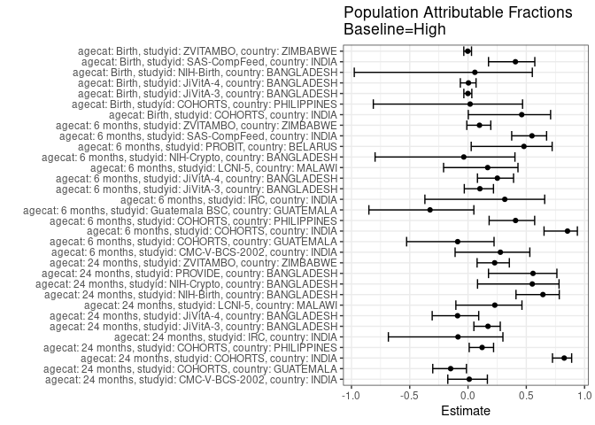

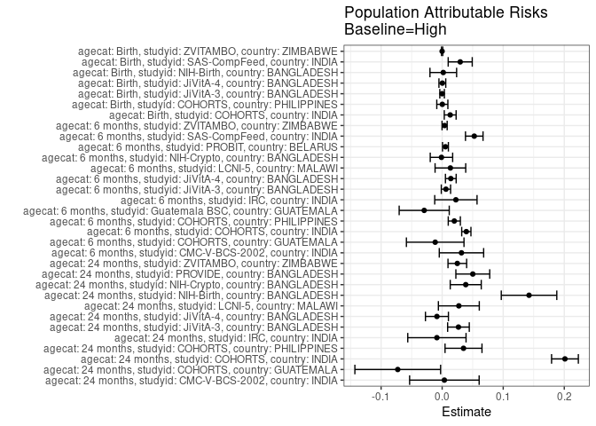

## Results Table

### Parameter: TSM

| agecat | studyid | country | intervention_level | baseline_level | estimate | ci_lower | ci_upper |
| --- | --- | --- | --- | --- | --- | --- | --- |
| Birth | COHORTS | INDIA | High | NA | 0.0154048 | 0.0056038 | 0.0252058 |
| Birth | COHORTS | INDIA | Low | NA | 0.0419288 | 0.0325000 | 0.0513576 |
| Birth | COHORTS | INDIA | Medium | NA | 0.0237914 | 0.0181081 | 0.0294746 |
| Birth | COHORTS | PHILIPPINES | High | NA | 0.0148084 | 0.0048017 | 0.0248151 |
| Birth | COHORTS | PHILIPPINES | Low | NA | 0.0186825 | 0.0080271 | 0.0293378 |
| Birth | COHORTS | PHILIPPINES | Medium | NA | 0.0144567 | 0.0069719 | 0.0219415 |
| Birth | JiVitA-3 | BANGLADESH | High | NA | 0.1092595 | 0.1034295 | 0.1150895 |
| Birth | JiVitA-3 | BANGLADESH | Low | NA | 0.1114186 | 0.1063181 | 0.1165190 |
| Birth | JiVitA-3 | BANGLADESH | Medium | NA | 0.1129864 | 0.1068376 | 0.1191352 |
| Birth | JiVitA-4 | BANGLADESH | High | NA | 0.0823995 | 0.0691916 | 0.0956074 |
| Birth | JiVitA-4 | BANGLADESH | Low | NA | 0.0854464 | 0.0726722 | 0.0982205 |
| Birth | JiVitA-4 | BANGLADESH | Medium | NA | 0.0791800 | 0.0666824 | 0.0916775 |
| Birth | NIH-Birth | BANGLADESH | High | NA | 0.0294118 | 0.0039927 | 0.0548308 |
| Birth | NIH-Birth | BANGLADESH | Low | NA | 0.0401786 | 0.0144406 | 0.0659165 |
| Birth | NIH-Birth | BANGLADESH | Medium | NA | 0.0233645 | 0.0031090 | 0.0436200 |
| Birth | SAS-CompFeed | INDIA | High | NA | 0.0431140 | 0.0298965 | 0.0563315 |
| Birth | SAS-CompFeed | INDIA | Low | NA | 0.0838651 | 0.0620966 | 0.1056335 |
| Birth | SAS-CompFeed | INDIA | Medium | NA | 0.0583095 | 0.0286509 | 0.0879680 |
| Birth | ZVITAMBO | ZIMBABWE | High | NA | 0.0319837 | 0.0288916 | 0.0350757 |
| Birth | ZVITAMBO | ZIMBABWE | Low | NA | 0.0317210 | 0.0276464 | 0.0357956 |
| Birth | ZVITAMBO | ZIMBABWE | Medium | NA | 0.0312735 | 0.0276716 | 0.0348754 |
| 6 months | CMC-V-BCS-2002 | INDIA | High | NA | 0.0822073 | 0.0393626 | 0.1250520 |
| 6 months | CMC-V-BCS-2002 | INDIA | Low | NA | 0.1533952 | 0.0835181 | 0.2232723 |
| 6 months | CMC-V-BCS-2002 | INDIA | Medium | NA | 0.1202219 | 0.0585548 | 0.1818891 |
| 6 months | COHORTS | GUATEMALA | High | NA | 0.1395483 | 0.0875225 | 0.1915742 |
| 6 months | COHORTS | GUATEMALA | Low | NA | 0.1358714 | 0.1042229 | 0.1675200 |
| 6 months | COHORTS | GUATEMALA | Medium | NA | 0.0993314 | 0.0656792 | 0.1329836 |
| 6 months | COHORTS | INDIA | High | NA | 0.0067935 | 0.0008586 | 0.0127284 |
| 6 months | COHORTS | INDIA | Low | NA | 0.0782217 | 0.0657358 | 0.0907077 |
| 6 months | COHORTS | INDIA | Medium | NA | 0.0368966 | 0.0300351 | 0.0437580 |

[output cut: 66 more lines]

### Parameter: E(Y)

| agecat | studyid | country | intervention_level | baseline_level | estimate | ci_lower | ci_upper |
| --- | --- | --- | --- | --- | --- | --- | --- |
| Birth | COHORTS | INDIA | NA | NA | 0.0285660 | 0.0240448 | 0.0330871 |
| Birth | COHORTS | PHILIPPINES | NA | NA | 0.0150820 | 0.0107558 | 0.0194081 |
| Birth | JiVitA-3 | BANGLADESH | NA | NA | 0.1091541 | 0.1045948 | 0.1137135 |
| Birth | JiVitA-4 | BANGLADESH | NA | NA | 0.0827121 | 0.0710164 | 0.0944078 |
| Birth | NIH-Birth | BANGLADESH | NA | NA | 0.0312500 | 0.0174085 | 0.0450915 |
| Birth | SAS-CompFeed | INDIA | NA | NA | 0.0726837 | 0.0523147 | 0.0930527 |
| Birth | ZVITAMBO | ZIMBABWE | NA | NA | 0.0319018 | 0.0289755 | 0.0348282 |
| 6 months | CMC-V-BCS-2002 | INDIA | NA | NA | 0.1138211 | 0.0813725 | 0.1462698 |
| 6 months | COHORTS | GUATEMALA | NA | NA | 0.1281513 | 0.1069071 | 0.1493954 |
| 6 months | COHORTS | INDIA | NA | NA | 0.0463699 | 0.0407674 | 0.0519723 |
| 6 months | COHORTS | PHILIPPINES | NA | NA | 0.0487445 | 0.0406327 | 0.0568562 |
| 6 months | Guatemala BSC | GUATEMALA | NA | NA | 0.0902527 | 0.0564475 | 0.1240580 |
| 6 months | IRC | INDIA | NA | NA | 0.0712531 | 0.0462303 | 0.0962759 |
| 6 months | JiVitA-3 | BANGLADESH | NA | NA | 0.0606764 | 0.0568167 | 0.0645362 |
| 6 months | JiVitA-4 | BANGLADESH | NA | NA | 0.0562474 | 0.0494699 | 0.0630249 |
| 6 months | LCNI-5 | MALAWI | NA | NA | 0.0799508 | 0.0612962 | 0.0986054 |
| 6 months | NIH-Crypto | BANGLADESH | NA | NA | 0.0321678 | 0.0192256 | 0.0451101 |
| 6 months | PROBIT | BELARUS | NA | NA | 0.0112310 | 0.0054733 | 0.0169886 |
| 6 months | SAS-CompFeed | INDIA | NA | NA | 0.0958084 | 0.0774939 | 0.1141229 |
| 6 months | ZVITAMBO | ZIMBABWE | NA | NA | 0.0405546 | 0.0363986 | 0.0447105 |
| 24 months | CMC-V-BCS-2002 | INDIA | NA | NA | 0.3369272 | 0.2887662 | 0.3850883 |
| 24 months | COHORTS | GUATEMALA | NA | NA | 0.4881741 | 0.4580257 | 0.5183225 |
| 24 months | COHORTS | INDIA | NA | NA | 0.2436875 | 0.2306994 | 0.2566756 |
| 24 months | COHORTS | PHILIPPINES | NA | NA | 0.2891616 | 0.2711872 | 0.3071359 |
| 24 months | IRC | INDIA | NA | NA | 0.1002445 | 0.0711031 | 0.1293859 |
| 24 months | JiVitA-3 | BANGLADESH | NA | NA | 0.1558984 | 0.1471655 | 0.1646313 |
| 24 months | JiVitA-4 | BANGLADESH | NA | NA | 0.0953385 | 0.0857703 | 0.1049067 |
| 24 months | LCNI-5 | MALAWI | NA | NA | 0.1188811 | 0.0923348 | 0.1454274 |
| 24 months | NIH-Birth | BANGLADESH | NA | NA | 0.2214452 | 0.1821080 | 0.2607825 |
| 24 months | NIH-Crypto | BANGLADESH | NA | NA | 0.0700389 | 0.0479542 | 0.0921236 |
| 24 months | PROVIDE | BANGLADESH | NA | NA | 0.0899654 | 0.0666186 | 0.1133122 |
| 24 months | ZVITAMBO | ZIMBABWE | NA | NA | 0.1086028 | 0.0935351 | 0.1236705 |

### Parameter: RR

| agecat | studyid | country | intervention_level | baseline_level | estimate | ci_lower | ci_upper |
| --- | --- | --- | --- | --- | --- | --- | --- |
| Birth | COHORTS | INDIA | High | High | 1.0000000 | 1.0000000 | 1.0000000 |
| Birth | COHORTS | INDIA | Low | High | 2.7218055 | 1.3856671 | 5.3463238 |
| Birth | COHORTS | INDIA | Medium | High | 1.5444137 | 0.7825955 | 3.0478243 |
| Birth | COHORTS | PHILIPPINES | High | High | 1.0000000 | 1.0000000 | 1.0000000 |
| Birth | COHORTS | PHILIPPINES | Low | High | 1.2616113 | 0.5210975 | 3.0544438 |
| Birth | COHORTS | PHILIPPINES | Medium | High | 0.9762508 | 0.4168529 | 2.2863355 |
| Birth | JiVitA-3 | BANGLADESH | High | High | 1.0000000 | 1.0000000 | 1.0000000 |
| Birth | JiVitA-3 | BANGLADESH | Low | High | 1.0197607 | 0.9760955 | 1.0653792 |
| Birth | JiVitA-3 | BANGLADESH | Medium | High | 1.0341105 | 0.9826274 | 1.0882910 |
| Birth | JiVitA-4 | BANGLADESH | High | High | 1.0000000 | 1.0000000 | 1.0000000 |
| Birth | JiVitA-4 | BANGLADESH | Low | High | 1.0369767 | 0.9108605 | 1.1805547 |
| Birth | JiVitA-4 | BANGLADESH | Medium | High | 0.9609278 | 0.8384236 | 1.1013314 |
| Birth | NIH-Birth | BANGLADESH | High | High | 1.0000000 | 1.0000000 | 1.0000000 |
| Birth | NIH-Birth | BANGLADESH | Low | High | 1.3660714 | 0.4658790 | 4.0056565 |
| Birth | NIH-Birth | BANGLADESH | Medium | High | 0.7943925 | 0.2335614 | 2.7018994 |
| Birth | SAS-CompFeed | INDIA | High | High | 1.0000000 | 1.0000000 | 1.0000000 |
| Birth | SAS-CompFeed | INDIA | Low | High | 1.9451936 | 1.2895449 | 2.9341964 |
| Birth | SAS-CompFeed | INDIA | Medium | High | 1.3524491 | 0.8175123 | 2.2374202 |
| Birth | ZVITAMBO | ZIMBABWE | High | High | 1.0000000 | 1.0000000 | 1.0000000 |
| Birth | ZVITAMBO | ZIMBABWE | Low | High | 0.9917857 | 0.8917588 | 1.1030325 |
| Birth | ZVITAMBO | ZIMBABWE | Medium | High | 0.9777953 | 0.8942430 | 1.0691541 |
| 6 months | CMC-V-BCS-2002 | INDIA | High | High | 1.0000000 | 1.0000000 | 1.0000000 |
| 6 months | CMC-V-BCS-2002 | INDIA | Low | High | 1.8659558 | 0.9324981 | 3.7338316 |
| 6 months | CMC-V-BCS-2002 | INDIA | Medium | High | 1.4624237 | 0.7034526 | 3.0402657 |
| 6 months | COHORTS | GUATEMALA | High | High | 1.0000000 | 1.0000000 | 1.0000000 |
| 6 months | COHORTS | GUATEMALA | Low | High | 0.9736512 | 0.6282608 | 1.5089222 |
| 6 months | COHORTS | GUATEMALA | Medium | High | 0.7118065 | 0.4310833 | 1.1753378 |
| 6 months | COHORTS | INDIA | High | High | 1.0000000 | 1.0000000 | 1.0000000 |
| 6 months | COHORTS | INDIA | Low | High | 11.5142375 | 4.7374574 | 27.9849831 |
| 6 months | COHORTS | INDIA | Medium | High | 5.4311724 | 2.2232285 | 13.2679273 |

[output cut: 66 more lines]

### Parameter: PAR

| agecat | studyid | country | intervention_level | baseline_level | estimate | ci_lower | ci_upper |
| --- | --- | --- | --- | --- | --- | --- | --- |
| Birth | COHORTS | INDIA | High | NA | 0.0131612 | 0.0034678 | 0.0228545 |
| Birth | COHORTS | PHILIPPINES | High | NA | 0.0002736 | -0.0088053 | 0.0093524 |
| Birth | JiVitA-3 | BANGLADESH | High | NA | -0.0001054 | -0.0038385 | 0.0036278 |
| Birth | JiVitA-4 | BANGLADESH | High | NA | 0.0003126 | -0.0052580 | 0.0058832 |
| Birth | NIH-Birth | BANGLADESH | High | NA | 0.0018382 | -0.0199882 | 0.0236647 |
| Birth | SAS-CompFeed | INDIA | High | NA | 0.0295697 | 0.0098802 | 0.0492592 |
| Birth | ZVITAMBO | ZIMBABWE | High | NA | -0.0000818 | -0.0011371 | 0.0009734 |
| 6 months | CMC-V-BCS-2002 | INDIA | High | NA | 0.0316138 | -0.0047225 | 0.0679501 |
| 6 months | COHORTS | GUATEMALA | High | NA | -0.0113971 | -0.0585581 | 0.0357639 |
| 6 months | COHORTS | INDIA | High | NA | 0.0395764 | 0.0320244 | 0.0471283 |
| 6 months | COHORTS | PHILIPPINES | High | NA | 0.0198821 | 0.0099720 | 0.0297922 |
| 6 months | Guatemala BSC | GUATEMALA | High | NA | -0.0294054 | -0.0704132 | 0.0116024 |
| 6 months | IRC | INDIA | High | NA | 0.0224726 | -0.0121801 | 0.0571253 |
| 6 months | JiVitA-3 | BANGLADESH | High | NA | 0.0061848 | -0.0014259 | 0.0137955 |
| 6 months | JiVitA-4 | BANGLADESH | High | NA | 0.0141578 | 0.0053764 | 0.0229392 |
| 6 months | LCNI-5 | MALAWI | High | NA | 0.0134802 | -0.0116171 | 0.0385775 |
| 6 months | NIH-Crypto | BANGLADESH | High | NA | -0.0011655 | -0.0195299 | 0.0171989 |
| 6 months | PROBIT | BELARUS | High | NA | 0.0053895 | 0.0005956 | 0.0101834 |
| 6 months | SAS-CompFeed | INDIA | High | NA | 0.0525681 | 0.0381918 | 0.0669445 |
| 6 months | ZVITAMBO | ZIMBABWE | High | NA | 0.0039897 | -0.0002035 | 0.0081828 |
| 24 months | CMC-V-BCS-2002 | INDIA | High | NA | 0.0036419 | -0.0533065 | 0.0605903 |
| 24 months | COHORTS | GUATEMALA | High | NA | -0.0727452 | -0.1429500 | -0.0025404 |
| 24 months | COHORTS | INDIA | High | NA | 0.2011198 | 0.1791924 | 0.2230473 |
| 24 months | COHORTS | PHILIPPINES | High | NA | 0.0349683 | 0.0047140 | 0.0652225 |
| 24 months | IRC | INDIA | High | NA | -0.0086185 | -0.0563522 | 0.0391153 |
| 24 months | JiVitA-3 | BANGLADESH | High | NA | 0.0266908 | 0.0089611 | 0.0444204 |
| 24 months | JiVitA-4 | BANGLADESH | High | NA | -0.0085546 | -0.0273733 | 0.0102640 |
| 24 months | LCNI-5 | MALAWI | High | NA | 0.0273180 | -0.0061758 | 0.0608118 |
| 24 months | NIH-Birth | BANGLADESH | High | NA | 0.1422889 | 0.0968250 | 0.1877528 |
| 24 months | NIH-Crypto | BANGLADESH | High | NA | 0.0386253 | 0.0132246 | 0.0640260 |
| 24 months | PROVIDE | BANGLADESH | High | NA | 0.0501644 | 0.0224541 | 0.0778747 |
| 24 months | ZVITAMBO | ZIMBABWE | High | NA | 0.0248178 | 0.0095545 | 0.0400810 |

### Parameter: PAF

| agecat | studyid | country | intervention_level | baseline_level | estimate | ci_lower | ci_upper |
| --- | --- | --- | --- | --- | --- | --- | --- |
| Birth | COHORTS | INDIA | High | NA | 0.4607293 | 0.0022133 | 0.7085421 |
| Birth | COHORTS | PHILIPPINES | High | NA | 0.0181382 | -0.8125517 | 0.4681241 |
| Birth | JiVitA-3 | BANGLADESH | High | NA | -0.0009654 | -0.0357580 | 0.0326585 |
| Birth | JiVitA-4 | BANGLADESH | High | NA | 0.0037795 | -0.0659295 | 0.0689298 |
| Birth | NIH-Birth | BANGLADESH | High | NA | 0.0588235 | -0.9758330 | 0.5516761 |
| Birth | SAS-CompFeed | INDIA | High | NA | 0.4068273 | 0.1759359 | 0.5730261 |
| Birth | ZVITAMBO | ZIMBABWE | High | NA | -0.0025653 | -0.0362006 | 0.0299783 |
| 6 months | CMC-V-BCS-2002 | INDIA | High | NA | 0.2777499 | -0.1107960 | 0.5303862 |
| 6 months | COHORTS | GUATEMALA | High | NA | -0.0889346 | -0.5268617 | 0.2233884 |
| 6 months | COHORTS | INDIA | High | NA | 0.8534936 | 0.6522116 | 0.9382840 |
| 6 months | COHORTS | PHILIPPINES | High | NA | 0.4078840 | 0.1811754 | 0.5718236 |
| 6 months | Guatemala BSC | GUATEMALA | High | NA | -0.3258120 | -0.8505799 | 0.0501478 |
| 6 months | IRC | INDIA | High | NA | 0.3153911 | -0.3699702 | 0.6578835 |
| 6 months | JiVitA-3 | BANGLADESH | High | NA | 0.1019310 | -0.0319754 | 0.2184622 |
| 6 months | JiVitA-4 | BANGLADESH | High | NA | 0.2517059 | 0.0809164 | 0.3907583 |
| 6 months | LCNI-5 | MALAWI | High | NA | 0.1686066 | -0.2096471 | 0.4285813 |
| 6 months | NIH-Crypto | BANGLADESH | High | NA | -0.0362319 | -0.7974273 | 0.4026037 |
| 6 months | PROBIT | BELARUS | High | NA | 0.4798787 | 0.0273719 | 0.7218607 |
| 6 months | SAS-CompFeed | INDIA | High | NA | 0.5486796 | 0.3747695 | 0.6742161 |
| 6 months | ZVITAMBO | ZIMBABWE | High | NA | 0.0983773 | -0.0104690 | 0.1954989 |
| 24 months | CMC-V-BCS-2002 | INDIA | High | NA | 0.0108092 | -0.1735111 | 0.1661789 |
| 24 months | COHORTS | GUATEMALA | High | NA | -0.1490148 | -0.3025267 | -0.0135954 |
| 24 months | COHORTS | INDIA | High | NA | 0.8253186 | 0.7246749 | 0.8891725 |
| 24 months | COHORTS | PHILIPPINES | High | NA | 0.1209298 | 0.0102325 | 0.2192465 |
| 24 months | IRC | INDIA | High | NA | -0.0859743 | -0.6833790 | 0.2994209 |
| 24 months | JiVitA-3 | BANGLADESH | High | NA | 0.1712062 | 0.0503943 | 0.2766480 |
| 24 months | JiVitA-4 | BANGLADESH | High | NA | -0.0897290 | -0.3074672 | 0.0917482 |
| 24 months | LCNI-5 | MALAWI | High | NA | 0.2297927 | -0.1042726 | 0.4627964 |
| 24 months | NIH-Birth | BANGLADESH | High | NA | 0.6425467 | 0.4116110 | 0.7828429 |
| 24 months | NIH-Crypto | BANGLADESH | High | NA | 0.5514834 | 0.0815919 | 0.7809611 |
| 24 months | PROVIDE | BANGLADESH | High | NA | 0.5575966 | 0.1758141 | 0.7625284 |
| 24 months | ZVITAMBO | ZIMBABWE | High | NA | 0.2285187 | 0.0779103 | 0.3545277 |